### RiskSpan Data Analysis

Loan Default is one of the major problems faced by the Financial Institutions. In a lot of cases simple statistical approaches fail to identify some patterns which can precisely be located by ensemble models. We have shown a demonstration of the same in my analysis wherein firstly, we try to identify the most the relevant features for our dependant variable and then use them for prediction. Initially we tried using the Logistric Regression Approach, however, it failed to give us a desired accuracy. Then we shifted to ensembe methods like decision trees and we successful to generate a model which would predict the loan_default probability of a customer for the bank and equip the banks to avoid the losses The Accuracy received my Decision Tree is 98%! Hurray!

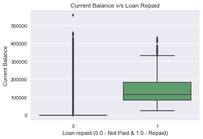

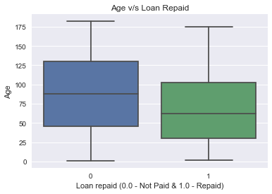

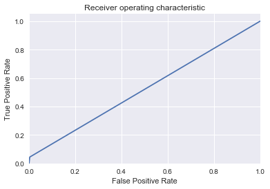

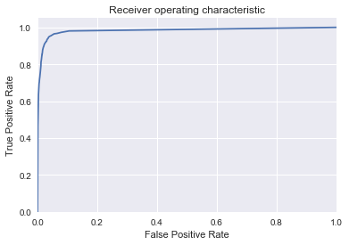

2. bitcamp-master : Includes files for the Riskspan data. All the files are present in the orginal “txt” as well modified “csv” format.
   1. Issuance_Data.csv
   2. Loan_health.csv
   3. Loan_origin.csv
3. Bitcamp19_Visualization_FINRA.pptx : This module describes the Exploratory analysis of the IARD Data. It identified various intriuging patter where we can see the Individuals that are registered in a particular state (Most of the cases it was Texas) were currently employed in California. It will be interesting to investigate this pattern observed in the dataset. One more very important pattern that was observed was “30%” of the Individuals present in the Registeration feeds had criminal records. This is a point which requires investigation from the authorized firms.
4. Bitcamp19_RiskSpan.pptx : This modules shows some plots that describe the movement of loan variables with respect to the interest rate or the type of loan.

Both of the files are also present as Tableau Files